# Risk Factor Analysis

## Outcome Variable

**Outcome Variable:** ever_sstunted

## Predictor Variables

**Intervention Variable:** meducyrs

**Adjustment Set:**

- arm
- W_mage
- feducyrs
- hhwealth_quart
- W_mhtcm
- W_mwtkg
- W_mbmi
- W_gagebrth
- W_birthwt
- W_birthlen
- single
- W_nrooms
- impsan
- delta_W_mage
- delta_feducyrs
- delta_hhwealth_quart
- delta_W_mhtcm
- delta_W_mwtkg
- delta_W_mbmi
- delta_W_gagebrth
- delta_W_birthwt
- delta_W_birthlen
- delta_single
- delta_W_nrooms
- delta_impsan

## Stratifying Variables

The analysis was stratified on these variable(s):

- agecat
- studyid
- country

## Data Summary

| agecat | studyid | country | meducyrs | ever_sstunted | n_cell | n |
| --- | --- | --- | --- | --- | --- | --- |
| 0-24 months | ki0047075b-MAL-ED | BANGLADESH | High | 0 | 64 | 214 |
| 0-24 months | ki0047075b-MAL-ED | BANGLADESH | High | 1 | 14 | 214 |
| 0-24 months | ki0047075b-MAL-ED | BANGLADESH | Low | 0 | 55 | 214 |
| 0-24 months | ki0047075b-MAL-ED | BANGLADESH | Low | 1 | 15 | 214 |
| 0-24 months | ki0047075b-MAL-ED | BANGLADESH | Medium | 0 | 55 | 214 |
| 0-24 months | ki0047075b-MAL-ED | BANGLADESH | Medium | 1 | 11 | 214 |
| 0-24 months | ki0047075b-MAL-ED | BRAZIL | High | 0 | 69 | 232 |
| 0-24 months | ki0047075b-MAL-ED | BRAZIL | High | 1 | 10 | 232 |
| 0-24 months | ki0047075b-MAL-ED | BRAZIL | Low | 0 | 60 | 232 |
| 0-24 months | ki0047075b-MAL-ED | BRAZIL | Low | 1 | 3 | 232 |
| 0-24 months | ki0047075b-MAL-ED | BRAZIL | Medium | 0 | 81 | 232 |
| 0-24 months | ki0047075b-MAL-ED | BRAZIL | Medium | 1 | 9 | 232 |
| 0-24 months | ki0047075b-MAL-ED | INDIA | High | 0 | 50 | 220 |
| 0-24 months | ki0047075b-MAL-ED | INDIA | High | 1 | 13 | 220 |
| 0-24 months | ki0047075b-MAL-ED | INDIA | Low | 0 | 59 | 220 |
| 0-24 months | ki0047075b-MAL-ED | INDIA | Low | 1 | 17 | 220 |
| 0-24 months | ki0047075b-MAL-ED | INDIA | Medium | 0 | 64 | 220 |
| 0-24 months | ki0047075b-MAL-ED | INDIA | Medium | 1 | 17 | 220 |
| 0-24 months | ki0047075b-MAL-ED | NEPAL | High | 0 | 48 | 225 |
| 0-24 months | ki0047075b-MAL-ED | NEPAL | High | 1 | 5 | 225 |
| 0-24 months | ki0047075b-MAL-ED | NEPAL | Low | 0 | 88 | 225 |
| 0-24 months | ki0047075b-MAL-ED | NEPAL | Low | 1 | 8 | 225 |
| 0-24 months | ki0047075b-MAL-ED | NEPAL | Medium | 0 | 70 | 225 |
| 0-24 months | ki0047075b-MAL-ED | NEPAL | Medium | 1 | 6 | 225 |
| 0-24 months | ki0047075b-MAL-ED | PERU | High | 0 | 71 | 302 |
| 0-24 months | ki0047075b-MAL-ED | PERU | High | 1 | 20 | 302 |
| 0-24 months | ki0047075b-MAL-ED | PERU | Low | 0 | 83 | 302 |
| 0-24 months | ki0047075b-MAL-ED | PERU | Low | 1 | 21 | 302 |
| 0-24 months | ki0047075b-MAL-ED | PERU | Medium | 0 | 84 | 302 |
| 0-24 months | ki0047075b-MAL-ED | PERU | Medium | 1 | 23 | 302 |

[output cut: 282 more lines]

The following strata were considered:

- agecat: 0-24 months, studyid: ki0047075b-MAL-ED, country: BANGLADESH
- agecat: 0-24 months, studyid: ki0047075b-MAL-ED, country: BRAZIL
- agecat: 0-24 months, studyid: ki0047075b-MAL-ED, country: INDIA
- agecat: 0-24 months, studyid: ki0047075b-MAL-ED, country: NEPAL
- agecat: 0-24 months, studyid: ki0047075b-MAL-ED, country: PERU
- agecat: 0-24 months, studyid: ki0047075b-MAL-ED, country: SOUTH AFRICA
- agecat: 0-24 months, studyid: ki0047075b-MAL-ED, country: TANZANIA, UNITED REPUBLIC OF
- agecat: 0-24 months, studyid: ki1000108-CMC-V-BCS-2002, country: INDIA
- agecat: 0-24 months, studyid: ki1000108-IRC, country: INDIA
- agecat: 0-24 months, studyid: ki1000109-EE, country: PAKISTAN
- agecat: 0-24 months, studyid: ki1000304b-SAS-CompFeed, country: INDIA
- agecat: 0-24 months, studyid: ki1000304b-SAS-FoodSuppl, country: INDIA
- agecat: 0-24 months, studyid: ki1017093-NIH-Birth, country: BANGLADESH
- agecat: 0-24 months, studyid: ki1017093b-PROVIDE, country: BANGLADESH
- agecat: 0-24 months, studyid: ki1017093c-NIH-Crypto, country: BANGLADESH
- agecat: 0-24 months, studyid: ki1066203-TanzaniaChild2, country: TANZANIA, UNITED REPUBLIC OF
- agecat: 0-24 months, studyid: ki1112895-Guatemala BSC, country: GUATEMALA
- agecat: 0-24 months, studyid: ki1113344-GMS-Nepal, country: NEPAL
- agecat: 0-24 months, studyid: ki1119695-PROBIT, country: BELARUS
- agecat: 0-24 months, studyid: ki1126311-ZVITAMBO, country: ZIMBABWE
- agecat: 0-24 months, studyid: ki1135781-COHORTS, country: GUATEMALA
- agecat: 0-24 months, studyid: ki1135781-COHORTS, country: INDIA
- agecat: 0-24 months, studyid: ki1135781-COHORTS, country: PHILIPPINES
- agecat: 0-24 months, studyid: ki1148112-LCNI-5, country: MALAWI
- agecat: 0-24 months, studyid: kiGH5241-JiVitA-3, country: BANGLADESH
- agecat: 0-24 months, studyid: kiGH5241-JiVitA-4, country: BANGLADESH
- agecat: 0-6 months, studyid: ki0047075b-MAL-ED, country: BANGLADESH
- agecat: 0-6 months, studyid: ki0047075b-MAL-ED, country: BRAZIL
- agecat: 0-6 months, studyid: ki0047075b-MAL-ED, country: INDIA
- agecat: 0-6 months, studyid: ki0047075b-MAL-ED, country: NEPAL
- agecat: 0-6 months, studyid: ki0047075b-MAL-ED, country: PERU
- agecat: 0-6 months, studyid: ki0047075b-MAL-ED, country: SOUTH AFRICA
- agecat: 0-6 months, studyid: ki0047075b-MAL-ED, country: TANZANIA, UNITED REPUBLIC OF
- agecat: 0-6 months, studyid: ki1000108-CMC-V-BCS-2002, country: INDIA
- agecat: 0-6 months, studyid: ki1000108-IRC, country: INDIA
- agecat: 0-6 months, studyid: ki1000109-EE, country: PAKISTAN
- agecat: 0-6 months, studyid: ki1000304b-SAS-CompFeed, country: INDIA
- agecat: 0-6 months, studyid: ki1000304b-SAS-FoodSuppl, country: INDIA
- agecat: 0-6 months, studyid: ki1017093-NIH-Birth, country: BANGLADESH
- agecat: 0-6 months, studyid: ki1017093b-PROVIDE, country: BANGLADESH
- agecat: 0-6 months, studyid: ki1017093c-NIH-Crypto, country: BANGLADESH
- agecat: 0-6 months, studyid: ki1066203-TanzaniaChild2, country: TANZANIA, UNITED REPUBLIC OF
- agecat: 0-6 months, studyid: ki1112895-Guatemala BSC, country: GUATEMALA
- agecat: 0-6 months, studyid: ki1113344-GMS-Nepal, country: NEPAL
- agecat: 0-6 months, studyid: ki1119695-PROBIT, country: BELARUS
- agecat: 0-6 months, studyid: ki1126311-ZVITAMBO, country: ZIMBABWE
- agecat: 0-6 months, studyid: ki1135781-COHORTS, country: GUATEMALA
- agecat: 0-6 months, studyid: ki1135781-COHORTS, country: INDIA
- agecat: 0-6 months, studyid: ki1135781-COHORTS, country: PHILIPPINES
- agecat: 0-6 months, studyid: ki1148112-LCNI-5, country: MALAWI
- agecat: 0-6 months, studyid: kiGH5241-JiVitA-3, country: BANGLADESH
- agecat: 0-6 months, studyid: kiGH5241-JiVitA-4, country: BANGLADESH

### Dropped Strata

Some strata were dropped due to rare outcomes:

- agecat: 0-24 months, studyid: ki0047075b-MAL-ED, country: BRAZIL
- agecat: 0-6 months, studyid: ki0047075b-MAL-ED, country: BANGLADESH
- agecat: 0-6 months, studyid: ki0047075b-MAL-ED, country: BRAZIL
- agecat: 0-6 months, studyid: ki0047075b-MAL-ED, country: INDIA
- agecat: 0-6 months, studyid: ki0047075b-MAL-ED, country: NEPAL
- agecat: 0-6 months, studyid: ki0047075b-MAL-ED, country: TANZANIA, UNITED REPUBLIC OF
- agecat: 0-6 months, studyid: ki1000304b-SAS-FoodSuppl, country: INDIA
- agecat: 0-6 months, studyid: ki1017093b-PROVIDE, country: BANGLADESH
- agecat: 0-6 months, studyid: ki1066203-TanzaniaChild2, country: TANZANIA, UNITED REPUBLIC OF
- agecat: 0-6 months, studyid: ki1112895-Guatemala BSC, country: GUATEMALA
- agecat: 0-6 months, studyid: ki1148112-LCNI-5, country: MALAWI

## Methods Detail

We’re interested in the causal parameters $E[Y_a]$ for all values of $a \in \mathcal{A}$. These parameters represent the mean outcome if, possibly contrary to fact, we intervened to set all units to have $A=a$. Under the randomization and positivity assumptions, these are identified by the statistical parameters $\psi_a=E_W[E_{Y|A,W}(Y|A=a,W)]$. In addition, we’re interested in the mean of $Y$, $E[Y]$ under no intervention (the observed mean). We will estimate these parameters by using SuperLearner to fit the relevant likelihood factors – $E_{Y|A,W}(Y|A=a,W)$ and $p(A=a|W)$, and then updating our likelihood fit using a joint TMLE.

For unadjusted analyses ($W=\{\}$), initial likelihoods were estimated using Lrnr_glm to estimate the simple $E(Y|A)$ and Lrnr_mean to estimate $p(A)$. For adjusted analyses, a small library containing Lrnr_glmnet, Lrnr_xgboost, and Lrnr_mean was used.

Having estimated these parameters, we will then use the delta method to estimate relative risks and attributable risks relative to a prespecified baseline level of $A$.

# Results Detail

## Results Plots

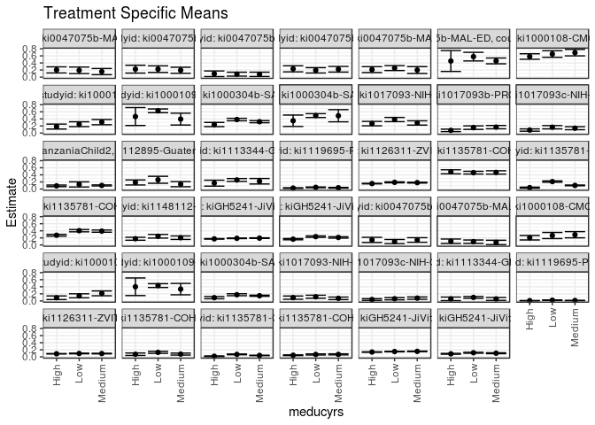

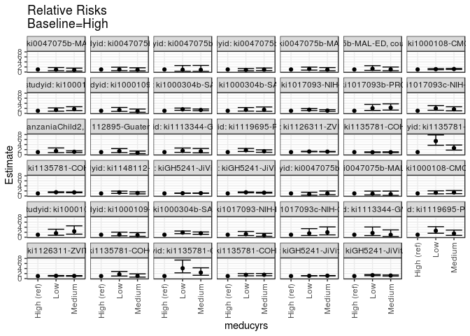

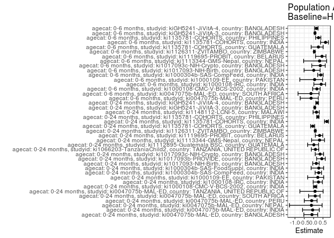

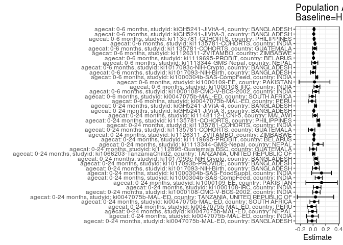

## Results Table

### Parameter: TSM

| agecat | studyid | country | intervention_level | baseline_level | estimate | ci_lower | ci_upper |
| --- | --- | --- | --- | --- | --- | --- | --- |
| 0-24 months | ki0047075b-MAL-ED | BANGLADESH | High | NA | 0.2037312 | 0.1178563 | 0.2896062 |
| 0-24 months | ki0047075b-MAL-ED | BANGLADESH | Low | NA | 0.1926059 | 0.0999751 | 0.2852367 |
| 0-24 months | ki0047075b-MAL-ED | BANGLADESH | Medium | NA | 0.1559952 | 0.0687441 | 0.2432464 |
| 0-24 months | ki0047075b-MAL-ED | INDIA | High | NA | 0.2248450 | 0.1138422 | 0.3358479 |
| 0-24 months | ki0047075b-MAL-ED | INDIA | Low | NA | 0.2253605 | 0.1323312 | 0.3183898 |
| 0-24 months | ki0047075b-MAL-ED | INDIA | Medium | NA | 0.1937449 | 0.1085059 | 0.2789840 |
| 0-24 months | ki0047075b-MAL-ED | NEPAL | High | NA | 0.0943396 | 0.0154705 | 0.1732088 |
| 0-24 months | ki0047075b-MAL-ED | NEPAL | Low | NA | 0.0833333 | 0.0279225 | 0.1387442 |
| 0-24 months | ki0047075b-MAL-ED | NEPAL | Medium | NA | 0.0789474 | 0.0181871 | 0.1397076 |
| 0-24 months | ki0047075b-MAL-ED | PERU | High | NA | 0.2340737 | 0.1481048 | 0.3200427 |
| 0-24 months | ki0047075b-MAL-ED | PERU | Low | NA | 0.1919764 | 0.1168811 | 0.2670717 |
| 0-24 months | ki0047075b-MAL-ED | PERU | Medium | NA | 0.2219694 | 0.1425797 | 0.3013591 |
| 0-24 months | ki0047075b-MAL-ED | SOUTH AFRICA | High | NA | 0.2120501 | 0.1287986 | 0.2953015 |
| 0-24 months | ki0047075b-MAL-ED | SOUTH AFRICA | Low | NA | 0.2554448 | 0.1855965 | 0.3252930 |
| 0-24 months | ki0047075b-MAL-ED | SOUTH AFRICA | Medium | NA | 0.1989835 | 0.1023769 | 0.2955902 |
| 0-24 months | ki0047075b-MAL-ED | TANZANIA, UNITED REPUBLIC OF | High | NA | 0.4545455 | 0.1596129 | 0.7494780 |
| 0-24 months | ki0047075b-MAL-ED | TANZANIA, UNITED REPUBLIC OF | Low | NA | 0.5781250 | 0.4568521 | 0.6993979 |
| 0-24 months | ki0047075b-MAL-ED | TANZANIA, UNITED REPUBLIC OF | Medium | NA | 0.4577465 | 0.3756129 | 0.5398800 |
| 0-24 months | ki1000108-CMC-V-BCS-2002 | INDIA | High | NA | 0.5816873 | 0.5043469 | 0.6590277 |
| 0-24 months | ki1000108-CMC-V-BCS-2002 | INDIA | Low | NA | 0.6523082 | 0.5602507 | 0.7443656 |
| 0-24 months | ki1000108-CMC-V-BCS-2002 | INDIA | Medium | NA | 0.6905502 | 0.6002677 | 0.7808327 |
| 0-24 months | ki1000108-IRC | INDIA | High | NA | 0.1835758 | 0.1137561 | 0.2533955 |
| 0-24 months | ki1000108-IRC | INDIA | Low | NA | 0.2501824 | 0.1816187 | 0.3187461 |
| 0-24 months | ki1000108-IRC | INDIA | Medium | NA | 0.3087721 | 0.2354477 | 0.3820965 |
| 0-24 months | ki1000109-EE | PAKISTAN | High | NA | 0.4666667 | 0.2138629 | 0.7194704 |
| 0-24 months | ki1000109-EE | PAKISTAN | Low | NA | 0.6280488 | 0.5756732 | 0.6804244 |
| 0-24 months | ki1000109-EE | PAKISTAN | Medium | NA | 0.3939394 | 0.2270064 | 0.5608724 |
| 0-24 months | ki1000304b-SAS-CompFeed | INDIA | High | NA | 0.2412748 | 0.1819459 | 0.3006036 |
| 0-24 months | ki1000304b-SAS-CompFeed | INDIA | Low | NA | 0.3818969 | 0.3469713 | 0.4168225 |
| 0-24 months | ki1000304b-SAS-CompFeed | INDIA | Medium | NA | 0.3211522 | 0.2918245 | 0.3504799 |

[output cut: 93 more lines]

### Parameter: E(Y)

| agecat | studyid | country | intervention_level | baseline_level | estimate | ci_lower | ci_upper |
| --- | --- | --- | --- | --- | --- | --- | --- |
| 0-24 months | ki0047075b-MAL-ED | BANGLADESH | NA | NA | 0.1869159 | 0.1345620 | 0.2392698 |
| 0-24 months | ki0047075b-MAL-ED | INDIA | NA | NA | 0.2136364 | 0.1593519 | 0.2679208 |
| 0-24 months | ki0047075b-MAL-ED | NEPAL | NA | NA | 0.0844444 | 0.0480318 | 0.1208571 |
| 0-24 months | ki0047075b-MAL-ED | PERU | NA | NA | 0.2119205 | 0.1657530 | 0.2580880 |
| 0-24 months | ki0047075b-MAL-ED | SOUTH AFRICA | NA | NA | 0.2324841 | 0.1856873 | 0.2792809 |
| 0-24 months | ki0047075b-MAL-ED | TANZANIA, UNITED REPUBLIC OF | NA | NA | 0.4930876 | 0.4264146 | 0.5597605 |
| 0-24 months | ki1000108-CMC-V-BCS-2002 | INDIA | NA | NA | 0.6353887 | 0.5864772 | 0.6843003 |
| 0-24 months | ki1000108-IRC | INDIA | NA | NA | 0.2487805 | 0.2068840 | 0.2906770 |
| 0-24 months | ki1000109-EE | PAKISTAN | NA | NA | 0.6010638 | 0.5515023 | 0.6506253 |
| 0-24 months | ki1000304b-SAS-CompFeed | INDIA | NA | NA | 0.3307241 | 0.3024794 | 0.3589688 |
| 0-24 months | ki1000304b-SAS-FoodSuppl | INDIA | NA | NA | 0.4808612 | 0.4329065 | 0.5288160 |
| 0-24 months | ki1017093-NIH-Birth | BANGLADESH | NA | NA | 0.3116057 | 0.2753823 | 0.3478292 |
| 0-24 months | ki1017093b-PROVIDE | BANGLADESH | NA | NA | 0.1357143 | 0.1103250 | 0.1611036 |
| 0-24 months | ki1017093c-NIH-Crypto | BANGLADESH | NA | NA | 0.1306069 | 0.1066024 | 0.1546113 |
| 0-24 months | ki1066203-TanzaniaChild2 | TANZANIA, UNITED REPUBLIC OF | NA | NA | 0.0993294 | 0.0873254 | 0.1113334 |
| 0-24 months | ki1112895-Guatemala BSC | GUATEMALA | NA | NA | 0.1879433 | 0.1422658 | 0.2336207 |
| 0-24 months | ki1113344-GMS-Nepal | NEPAL | NA | NA | 0.2431655 | 0.2112486 | 0.2750823 |
| 0-24 months | ki1119695-PROBIT | BELARUS | NA | NA | 0.0394153 | 0.0310085 | 0.0478221 |
| 0-24 months | ki1126311-ZVITAMBO | ZIMBABWE | NA | NA | 0.1682795 | 0.1620941 | 0.1744649 |
| 0-24 months | ki1135781-COHORTS | GUATEMALA | NA | NA | 0.4638330 | 0.4371320 | 0.4905339 |
| 0-24 months | ki1135781-COHORTS | INDIA | NA | NA | 0.1320916 | 0.1234158 | 0.1407674 |
| 0-24 months | ki1135781-COHORTS | PHILIPPINES | NA | NA | 0.3561151 | 0.3391405 | 0.3730897 |
| 0-24 months | ki1148112-LCNI-5 | MALAWI | NA | NA | 0.2076167 | 0.1797361 | 0.2354973 |
| 0-24 months | kiGH5241-JiVitA-3 | BANGLADESH | NA | NA | 0.1846063 | 0.1789984 | 0.1902143 |
| 0-24 months | kiGH5241-JiVitA-4 | BANGLADESH | NA | NA | 0.2035431 | 0.1916695 | 0.2154167 |
| 0-6 months | ki0047075b-MAL-ED | PERU | NA | NA | 0.1258278 | 0.0883606 | 0.1632951 |
| 0-6 months | ki0047075b-MAL-ED | SOUTH AFRICA | NA | NA | 0.0923567 | 0.0602816 | 0.1244318 |
| 0-6 months | ki1000108-CMC-V-BCS-2002 | INDIA | NA | NA | 0.2472826 | 0.2031431 | 0.2914222 |
| 0-6 months | ki1000108-IRC | INDIA | NA | NA | 0.1512195 | 0.1164988 | 0.1859402 |
| 0-6 months | ki1000109-EE | PAKISTAN | NA | NA | 0.4228723 | 0.3728720 | 0.4728727 |
| 0-6 months | ki1000304b-SAS-CompFeed | INDIA | NA | NA | 0.1496732 | 0.1307571 | 0.1685893 |
| 0-6 months | ki1017093-NIH-Birth | BANGLADESH | NA | NA | 0.0937997 | 0.0709973 | 0.1166021 |
| 0-6 months | ki1017093c-NIH-Crypto | BANGLADESH | NA | NA | 0.0620053 | 0.0448256 | 0.0791849 |
| 0-6 months | ki1113344-GMS-Nepal | NEPAL | NA | NA | 0.0863309 | 0.0654358 | 0.1072261 |
| 0-6 months | ki1119695-PROBIT | BELARUS | NA | NA | 0.0142071 | 0.0107237 | 0.0176904 |
| 0-6 months | ki1126311-ZVITAMBO | ZIMBABWE | NA | NA | 0.0913301 | 0.0865643 | 0.0960959 |
| 0-6 months | ki1135781-COHORTS | GUATEMALA | NA | NA | 0.1011132 | 0.0831080 | 0.1191183 |
| 0-6 months | ki1135781-COHORTS | INDIA | NA | NA | 0.0473331 | 0.0418015 | 0.0528647 |
| 0-6 months | ki1135781-COHORTS | PHILIPPINES | NA | NA | 0.0624591 | 0.0538810 | 0.0710373 |
| 0-6 months | kiGH5241-JiVitA-3 | BANGLADESH | NA | NA | 0.1475283 | 0.1424745 | 0.1525821 |
| 0-6 months | kiGH5241-JiVitA-4 | BANGLADESH | NA | NA | 0.1013500 | 0.0923758 | 0.1103243 |

### Parameter: RR

| agecat | studyid | country | intervention_level | baseline_level | estimate | ci_lower | ci_upper |
| --- | --- | --- | --- | --- | --- | --- | --- |
| 0-24 months | ki0047075b-MAL-ED | BANGLADESH | High | High | 1.0000000 | 1.0000000 | 1.000000 |
| 0-24 months | ki0047075b-MAL-ED | BANGLADESH | Low | High | 0.9453922 | 0.5043978 | 1.771948 |
| 0-24 months | ki0047075b-MAL-ED | BANGLADESH | Medium | High | 0.7656913 | 0.3815480 | 1.536591 |
| 0-24 months | ki0047075b-MAL-ED | INDIA | High | High | 1.0000000 | 1.0000000 | 1.000000 |
| 0-24 months | ki0047075b-MAL-ED | INDIA | Low | High | 1.0022925 | 0.5289796 | 1.899110 |
| 0-24 months | ki0047075b-MAL-ED | INDIA | Medium | High | 0.8616821 | 0.4452098 | 1.667744 |
| 0-24 months | ki0047075b-MAL-ED | NEPAL | High | High | 1.0000000 | 1.0000000 | 1.000000 |
| 0-24 months | ki0047075b-MAL-ED | NEPAL | Low | High | 0.8833333 | 0.3035369 | 2.570619 |
| 0-24 months | ki0047075b-MAL-ED | NEPAL | Medium | High | 0.8368421 | 0.2686218 | 2.607028 |
| 0-24 months | ki0047075b-MAL-ED | PERU | High | High | 1.0000000 | 1.0000000 | 1.000000 |
| 0-24 months | ki0047075b-MAL-ED | PERU | Low | High | 0.8201538 | 0.4821009 | 1.395252 |
| 0-24 months | ki0047075b-MAL-ED | PERU | Medium | High | 0.9482884 | 0.5681179 | 1.582860 |
| 0-24 months | ki0047075b-MAL-ED | SOUTH AFRICA | High | High | 1.0000000 | 1.0000000 | 1.000000 |
| 0-24 months | ki0047075b-MAL-ED | SOUTH AFRICA | Low | High | 1.2046436 | 0.7484974 | 1.938773 |
| 0-24 months | ki0047075b-MAL-ED | SOUTH AFRICA | Medium | High | 0.9383800 | 0.5029678 | 1.750722 |
| 0-24 months | ki0047075b-MAL-ED | TANZANIA, UNITED REPUBLIC OF | High | High | 1.0000000 | 1.0000000 | 1.000000 |
| 0-24 months | ki0047075b-MAL-ED | TANZANIA, UNITED REPUBLIC OF | Low | High | 1.2718750 | 0.6431191 | 2.515344 |
| 0-24 months | ki0047075b-MAL-ED | TANZANIA, UNITED REPUBLIC OF | Medium | High | 1.0070423 | 0.5136638 | 1.974315 |
| 0-24 months | ki1000108-CMC-V-BCS-2002 | INDIA | High | High | 1.0000000 | 1.0000000 | 1.000000 |
| 0-24 months | ki1000108-CMC-V-BCS-2002 | INDIA | Low | High | 1.1214069 | 0.9234630 | 1.361780 |
| 0-24 months | ki1000108-CMC-V-BCS-2002 | INDIA | Medium | High | 1.1871502 | 0.9851189 | 1.430615 |
| 0-24 months | ki1000108-IRC | INDIA | High | High | 1.0000000 | 1.0000000 | 1.000000 |
| 0-24 months | ki1000108-IRC | INDIA | Low | High | 1.3628288 | 0.8558731 | 2.170067 |
| 0-24 months | ki1000108-IRC | INDIA | Medium | High | 1.6819869 | 1.0803101 | 2.618766 |
| 0-24 months | ki1000109-EE | PAKISTAN | High | High | 1.0000000 | 1.0000000 | 1.000000 |
| 0-24 months | ki1000109-EE | PAKISTAN | Low | High | 1.3458188 | 0.7779437 | 2.328225 |
| 0-24 months | ki1000109-EE | PAKISTAN | Medium | High | 0.8441558 | 0.4243530 | 1.679260 |
| 0-24 months | ki1000304b-SAS-CompFeed | INDIA | High | High | 1.0000000 | 1.0000000 | 1.000000 |
| 0-24 months | ki1000304b-SAS-CompFeed | INDIA | Low | High | 1.5828298 | 1.2022804 | 2.083832 |
| 0-24 months | ki1000304b-SAS-CompFeed | INDIA | Medium | High | 1.3310643 | 1.0381615 | 1.706606 |

[output cut: 93 more lines]

### Parameter: PAR

| agecat | studyid | country | intervention_level | baseline_level | estimate | ci_lower | ci_upper |
| --- | --- | --- | --- | --- | --- | --- | --- |
| 0-24 months | ki0047075b-MAL-ED | BANGLADESH | High | NA | -0.0168153 | -0.0847900 | 0.0511593 |
| 0-24 months | ki0047075b-MAL-ED | INDIA | High | NA | -0.0112086 | -0.1049217 | 0.0825044 |
| 0-24 months | ki0047075b-MAL-ED | NEPAL | High | NA | -0.0098952 | -0.0778345 | 0.0580441 |
| 0-24 months | ki0047075b-MAL-ED | PERU | High | NA | -0.0221532 | -0.0933706 | 0.0490642 |
| 0-24 months | ki0047075b-MAL-ED | SOUTH AFRICA | High | NA | 0.0204340 | -0.0497411 | 0.0906092 |
| 0-24 months | ki0047075b-MAL-ED | TANZANIA, UNITED REPUBLIC OF | High | NA | 0.0385421 | -0.2488804 | 0.3259646 |
| 0-24 months | ki1000108-CMC-V-BCS-2002 | INDIA | High | NA | 0.0537014 | -0.0045568 | 0.1119596 |
| 0-24 months | ki1000108-IRC | INDIA | High | NA | 0.0652047 | 0.0049653 | 0.1254441 |
| 0-24 months | ki1000109-EE | PAKISTAN | High | NA | 0.1343972 | -0.1131243 | 0.3819187 |
| 0-24 months | ki1000304b-SAS-CompFeed | INDIA | High | NA | 0.0894493 | 0.0329505 | 0.1459482 |
| 0-24 months | ki1000304b-SAS-FoodSuppl | INDIA | High | NA | 0.1334634 | -0.0226602 | 0.2895870 |
| 0-24 months | ki1017093-NIH-Birth | BANGLADESH | High | NA | 0.0445500 | -0.0091019 | 0.0982019 |
| 0-24 months | ki1017093b-PROVIDE | BANGLADESH | High | NA | 0.0595953 | 0.0273857 | 0.0918048 |
| 0-24 months | ki1017093c-NIH-Crypto | BANGLADESH | High | NA | 0.0452492 | 0.0154204 | 0.0750781 |
| 0-24 months | ki1066203-TanzaniaChild2 | TANZANIA, UNITED REPUBLIC OF | High | NA | 0.0098475 | -0.0097841 | 0.0294792 |
| 0-24 months | ki1112895-Guatemala BSC | GUATEMALA | High | NA | 0.0023714 | -0.0519017 | 0.0566445 |
| 0-24 months | ki1113344-GMS-Nepal | NEPAL | High | NA | 0.0774764 | -0.0040418 | 0.1589945 |
| 0-24 months | ki1119695-PROBIT | BELARUS | High | NA | 0.0126268 | 0.0042687 | 0.0209849 |
| 0-24 months | ki1126311-ZVITAMBO | ZIMBABWE | High | NA | 0.0152246 | 0.0094377 | 0.0210115 |
| 0-24 months | ki1135781-COHORTS | GUATEMALA | High | NA | -0.0217525 | -0.0723694 | 0.0288644 |
| 0-24 months | ki1135781-COHORTS | INDIA | High | NA | 0.0932753 | 0.0782640 | 0.1082866 |
| 0-24 months | ki1135781-COHORTS | PHILIPPINES | High | NA | 0.0816309 | 0.0603630 | 0.1028988 |
| 0-24 months | ki1148112-LCNI-5 | MALAWI | High | NA | 0.0317792 | -0.0030826 | 0.0666410 |
| 0-24 months | kiGH5241-JiVitA-3 | BANGLADESH | High | NA | 0.0114608 | 0.0053034 | 0.0176182 |
| 0-24 months | kiGH5241-JiVitA-4 | BANGLADESH | High | NA | 0.0389378 | 0.0243138 | 0.0535618 |
| 0-6 months | ki0047075b-MAL-ED | PERU | High | NA | -0.0169610 | -0.0764376 | 0.0425156 |
| 0-6 months | ki0047075b-MAL-ED | SOUTH AFRICA | High | NA | -0.0129065 | -0.0632808 | 0.0374679 |
| 0-6 months | ki1000108-CMC-V-BCS-2002 | INDIA | High | NA | 0.0429055 | -0.0070883 | 0.0928994 |
| 0-6 months | ki1000108-IRC | INDIA | High | NA | 0.0613675 | 0.0141531 | 0.1085818 |
| 0-6 months | ki1000109-EE | PAKISTAN | High | NA | 0.0228723 | -0.2204591 | 0.2662038 |
| 0-6 months | ki1000304b-SAS-CompFeed | INDIA | High | NA | 0.0571889 | 0.0401785 | 0.0741994 |
| 0-6 months | ki1017093-NIH-Birth | BANGLADESH | High | NA | 0.0005460 | -0.0386730 | 0.0397651 |
| 0-6 months | ki1017093c-NIH-Crypto | BANGLADESH | High | NA | 0.0221807 | 0.0000599 | 0.0443015 |
| 0-6 months | ki1113344-GMS-Nepal | NEPAL | High | NA | 0.0275074 | -0.0207563 | 0.0757711 |
| 0-6 months | ki1119695-PROBIT | BELARUS | High | NA | 0.0063892 | 0.0021259 | 0.0106525 |
| 0-6 months | ki1126311-ZVITAMBO | ZIMBABWE | High | NA | 0.0036156 | -0.0002021 | 0.0074332 |
| 0-6 months | ki1135781-COHORTS | GUATEMALA | High | NA | 0.0260450 | -0.0058161 | 0.0579061 |
| 0-6 months | ki1135781-COHORTS | INDIA | High | NA | 0.0301991 | 0.0201759 | 0.0402224 |
| 0-6 months | ki1135781-COHORTS | PHILIPPINES | High | NA | 0.0163291 | 0.0072918 | 0.0253663 |
| 0-6 months | kiGH5241-JiVitA-3 | BANGLADESH | High | NA | 0.0109401 | 0.0060994 | 0.0157807 |
| 0-6 months | kiGH5241-JiVitA-4 | BANGLADESH | High | NA | 0.0152851 | 0.0060446 | 0.0245257 |

### Parameter: PAF

| agecat | studyid | country | intervention_level | baseline_level | estimate | ci_lower | ci_upper |
| --- | --- | --- | --- | --- | --- | --- | --- |
| 0-24 months | ki0047075b-MAL-ED | BANGLADESH | High | NA | -0.0899621 | -0.5227975 | 0.2198454 |
| 0-24 months | ki0047075b-MAL-ED | INDIA | High | NA | -0.0524660 | -0.5958076 | 0.3058783 |
| 0-24 months | ki0047075b-MAL-ED | NEPAL | High | NA | -0.1171797 | -1.2929418 | 0.4556815 |
| 0-24 months | ki0047075b-MAL-ED | PERU | High | NA | -0.1045353 | -0.4974866 | 0.1853027 |
| 0-24 months | ki0047075b-MAL-ED | SOUTH AFRICA | High | NA | 0.0878942 | -0.2699320 | 0.3448965 |
| 0-24 months | ki0047075b-MAL-ED | TANZANIA, UNITED REPUBLIC OF | High | NA | 0.0781648 | -0.7350273 | 0.5102209 |
| 0-24 months | ki1000108-CMC-V-BCS-2002 | INDIA | High | NA | 0.0845174 | -0.0124207 | 0.1721738 |
| 0-24 months | ki1000108-IRC | INDIA | High | NA | 0.2620973 | -0.0238984 | 0.4682085 |
| 0-24 months | ki1000109-EE | PAKISTAN | High | NA | 0.2235988 | -0.3205244 | 0.5435156 |
| 0-24 months | ki1000304b-SAS-CompFeed | INDIA | High | NA | 0.2704651 | 0.0803071 | 0.4213056 |
| 0-24 months | ki1000304b-SAS-FoodSuppl | INDIA | High | NA | 0.2775508 | -0.1325212 | 0.5391407 |
| 0-24 months | ki1017093-NIH-Birth | BANGLADESH | High | NA | 0.1429691 | -0.0471375 | 0.2985621 |
| 0-24 months | ki1017093b-PROVIDE | BANGLADESH | High | NA | 0.4391229 | 0.1608041 | 0.6251375 |
| 0-24 months | ki1017093c-NIH-Crypto | BANGLADESH | High | NA | 0.3464538 | 0.0865003 | 0.5324326 |
| 0-24 months | ki1066203-TanzaniaChild2 | TANZANIA, UNITED REPUBLIC OF | High | NA | 0.0991401 | -0.1212652 | 0.2762207 |
| 0-24 months | ki1112895-Guatemala BSC | GUATEMALA | High | NA | 0.0126177 | -0.3228425 | 0.2630084 |
| 0-24 months | ki1113344-GMS-Nepal | NEPAL | High | NA | 0.3186159 | -0.1109928 | 0.5820996 |
| 0-24 months | ki1119695-PROBIT | BELARUS | High | NA | 0.3203529 | 0.0919109 | 0.4913272 |
| 0-24 months | ki1126311-ZVITAMBO | ZIMBABWE | High | NA | 0.0904723 | 0.0555553 | 0.1240983 |
| 0-24 months | ki1135781-COHORTS | GUATEMALA | High | NA | -0.0468972 | -0.1619834 | 0.0567905 |
| 0-24 months | ki1135781-COHORTS | INDIA | High | NA | 0.7061407 | 0.5810268 | 0.7938931 |
| 0-24 months | ki1135781-COHORTS | PHILIPPINES | High | NA | 0.2292262 | 0.1674189 | 0.2864452 |
| 0-24 months | ki1148112-LCNI-5 | MALAWI | High | NA | 0.1530666 | -0.0309160 | 0.3042147 |
| 0-24 months | kiGH5241-JiVitA-3 | BANGLADESH | High | NA | 0.0620825 | 0.0281928 | 0.0947904 |
| 0-24 months | kiGH5241-JiVitA-4 | BANGLADESH | High | NA | 0.1913001 | 0.1169117 | 0.2594222 |
| 0-6 months | ki0047075b-MAL-ED | PERU | High | NA | -0.1347953 | -0.7190798 | 0.2509014 |
| 0-6 months | ki0047075b-MAL-ED | SOUTH AFRICA | High | NA | -0.1397459 | -0.8365787 | 0.2926953 |
| 0-6 months | ki1000108-CMC-V-BCS-2002 | INDIA | High | NA | 0.1735081 | -0.0538006 | 0.3517855 |
| 0-6 months | ki1000108-IRC | INDIA | High | NA | 0.4058171 | 0.0140152 | 0.6419282 |
| 0-6 months | ki1000109-EE | PAKISTAN | High | NA | 0.0540881 | -0.7380042 | 0.4851857 |
| 0-6 months | ki1000304b-SAS-CompFeed | INDIA | High | NA | 0.3820920 | 0.2187696 | 0.5112706 |
| 0-6 months | ki1017093-NIH-Birth | BANGLADESH | High | NA | 0.0058214 | -0.5139519 | 0.3471451 |
| 0-6 months | ki1017093c-NIH-Crypto | BANGLADESH | High | NA | 0.3577232 | -0.0967760 | 0.6238799 |
| 0-6 months | ki1113344-GMS-Nepal | NEPAL | High | NA | 0.3186275 | -0.5372684 | 0.6979912 |
| 0-6 months | ki1119695-PROBIT | BELARUS | High | NA | 0.4497201 | 0.1031547 | 0.6623632 |
| 0-6 months | ki1126311-ZVITAMBO | ZIMBABWE | High | NA | 0.0395880 | -0.0030782 | 0.0804394 |
| 0-6 months | ki1135781-COHORTS | GUATEMALA | High | NA | 0.2575825 | -0.1308884 | 0.5126099 |
| 0-6 months | ki1135781-COHORTS | INDIA | High | NA | 0.6380126 | 0.3736686 | 0.7907899 |
| 0-6 months | ki1135781-COHORTS | PHILIPPINES | High | NA | 0.2614360 | 0.1085473 | 0.3881035 |
| 0-6 months | kiGH5241-JiVitA-3 | BANGLADESH | High | NA | 0.0741557 | 0.0408967 | 0.1062613 |
| 0-6 months | kiGH5241-JiVitA-4 | BANGLADESH | High | NA | 0.1508154 | 0.0549763 | 0.2369350 |